# R_머신러닝3_knn

Jang, Eunhee

2018년 5월 25일

# 3장. Knn 알고리즘

## 목차

1. knn이란 무엇인가?
2. knn이 필요한 이유
3. knn의 분류 실습1

### 3_1. knn이란 무엇인가?

##### 머신러닝의 종류 3가지

1. 지도학습
2. 비지도학습
3. 강화학습

> k nearest neighbors 의 약자로 머신러닝의 지도학습의 분류에 해당하는 알고리즘이다. (k 개의 가장 근처의 이웃들을 내 이웃으로 보고 분류하는 분류 방법)

##### 새로 들어온 데이터가 기존 데이터의 그룹에 어느 그룹에 속하는지 찾을 때 거리가 가장 가까운 데이터의 그룹을 자기 그룹으로 선택하는 아주 간단한 알고리즘이다.

##### 같은 거리안에 여러개의 그룹이 있으면 다수결에 의해서 가장 많은 그룹을 선택하는 분류 방법이다.

#### knn을 사회적인 관계로 보면?

사회적으로도 대략적으로 비슷한 사람들끼리 모이는 성질이 있다. 비슷한 취향의 사람들끼리 모여서 동호회를 만들고 비슷한 부류의 계층의 사람들끼리 친분을 맺기도 한다.

#### knn을 공간적인 관계로 보면?

가구점이 모이는 상가지역이 따로 형성되어있거나 한약방이 밀집되어 있는 지역이 따로 모여있는 경우가 많다.

> 이러한 특성을 가진 데이터를 분석목적으로 만들어진 알고리즘이 knn이다.

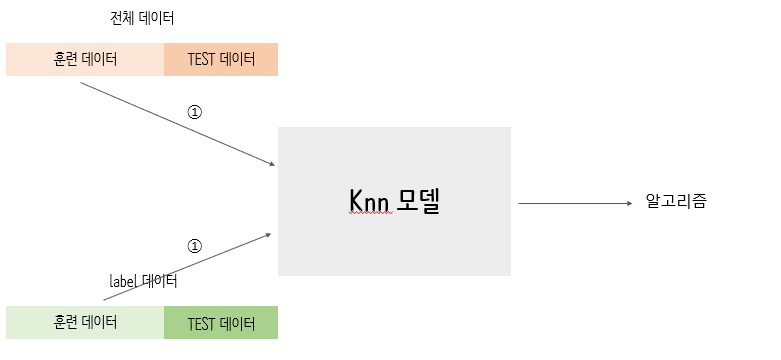

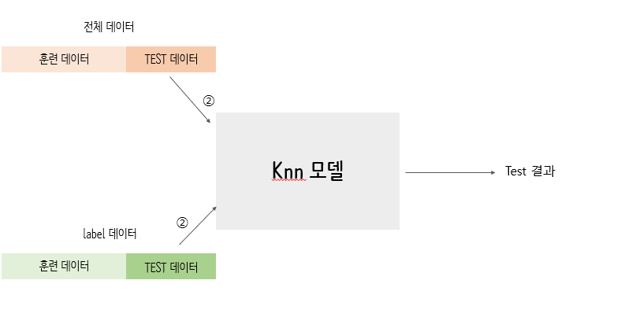

> 훈련데이터 : 머신러닝 모델을 훈련시킬 데이터  
> test 데이터 : 만들어진 훈련된 모델을 검증하는 데이터

### [knn 알고리즘 이론](https://www.slideshare.net/oracleyu23/knn-97741917)

### 3_2. knn이 필요한 이유

> 유방암의 종양의 크기에 대한 데이터(반지름, 둘레, 면적 등) 만 가지고 이종양이 악성인지 양성인지 예측할 수 있다면 환자에 대한 치료 스케줄에 큰 영향을 미칠 수 있기때문에 잘 훈련된(정확도 높은) 모델이 필요하다.

### 3_3. knn 분류 실습1(유방암 데이터)

```r
wbcd <- read.csv("C:/data/wisc_bc_data.csv", header = T, stringsAsFactors = FALSE)

nrow(wbcd)
```

```
## [1] 569
```

```r
# 컬럼확인
str(wbcd)
```

```
## 'data.frame':    569 obs. of  32 variables:
##  $ id               : int  87139402 8910251 905520 868871 9012568 906539 925291 87880 862989 89827 ...
##  $ diagnosis        : chr  "B" "B" "B" "B" ...
##  $ radius_mean      : num  12.3 10.6 11 11.3 15.2 ...
##  $ texture_mean     : num  12.4 18.9 16.8 13.4 13.2 ...
##  $ perimeter_mean   : num  78.8 69.3 70.9 73 97.7 ...
##  $ area_mean        : num  464 346 373 385 712 ...
##  $ smoothness_mean  : num  0.1028 0.0969 0.1077 0.1164 0.0796 ...
##  $ compactness_mean : num  0.0698 0.1147 0.078 0.1136 0.0693 ...
##  $ concavity_mean   : num  0.0399 0.0639 0.0305 0.0464 0.0339 ...
##  $ points_mean      : num  0.037 0.0264 0.0248 0.048 0.0266 ...
##  $ symmetry_mean    : num  0.196 0.192 0.171 0.177 0.172 ...
##  $ dimension_mean   : num  0.0595 0.0649 0.0634 0.0607 0.0554 ...
##  $ radius_se        : num  0.236 0.451 0.197 0.338 0.178 ...
##  $ texture_se       : num  0.666 1.197 1.387 1.343 0.412 ...
```

[output cut: 18 more lines]

#### 문제243. wbcd 569 건의 유방암 데이터를 훈련 데이터와 테스트 데이터로 나누시오

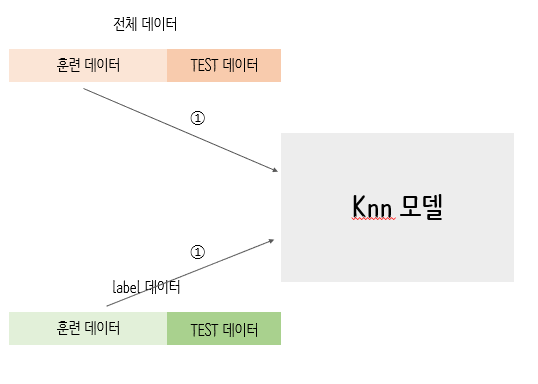

훈련데이터 : 머신러닝 모델을 훈련시킬 데이터 (80%)  
test 데이터: 만들어진 훈련된 모델을 검증하는 데이터 (20%)

```r
wbcd_train <- wbcd[1 : (nrow(wbcd) * 0.8),]
nrow(wbcd_train)
```

```
## [1] 455
```

```r
wbcd_test <- wbcd[(nrow(wbcd) *0.8):nrow(wbcd),]
nrow(wbcd_test)
```

```
## [1] 114
```

#### 문제244.stringsAsFactors = FALES 옵션을 사용해서 데이터를 로드한 wbcd 변수와 이 옵션을 사용하지 않고 데이터를 로드한 wbcd2와의 차이를 str로 비교해보시오

```r
wbcd <- read.csv("C:/data/wisc_bc_data.csv", header = T, stringsAsFactors = FALSE)
wbcd2 <- read.csv("C:/data/wisc_bc_data.csv", header = T)

str(wbcd)
```

```
## 'data.frame':    569 obs. of  32 variables:
##  $ id               : int  87139402 8910251 905520 868871 9012568 906539 925291 87880 862989 89827 ...
##  $ diagnosis        : chr  "B" "B" "B" "B" ...
##  $ radius_mean      : num  12.3 10.6 11 11.3 15.2 ...
##  $ texture_mean     : num  12.4 18.9 16.8 13.4 13.2 ...
##  $ perimeter_mean   : num  78.8 69.3 70.9 73 97.7 ...
##  $ area_mean        : num  464 346 373 385 712 ...
##  $ smoothness_mean  : num  0.1028 0.0969 0.1077 0.1164 0.0796 ...
##  $ compactness_mean : num  0.0698 0.1147 0.078 0.1136 0.0693 ...
##  $ concavity_mean   : num  0.0399 0.0639 0.0305 0.0464 0.0339 ...
##  $ points_mean      : num  0.037 0.0264 0.0248 0.048 0.0266 ...
##  $ symmetry_mean    : num  0.196 0.192 0.171 0.177 0.172 ...
##  $ dimension_mean   : num  0.0595 0.0649 0.0634 0.0607 0.0554 ...
##  $ radius_se        : num  0.236 0.451 0.197 0.338 0.178 ...
##  $ texture_se       : num  0.666 1.197 1.387 1.343 0.412 ...
```

[output cut: 18 more lines]

```r
str(wbcd2)
```

```
## 'data.frame':    569 obs. of  32 variables:
##  $ id               : int  87139402 8910251 905520 868871 9012568 906539 925291 87880 862989 89827 ...
##  $ diagnosis        : Factor w/ 2 levels "B","M": 1 1 1 1 1 1 1 2 1 1 ...
##  $ radius_mean      : num  12.3 10.6 11 11.3 15.2 ...
##  $ texture_mean     : num  12.4 18.9 16.8 13.4 13.2 ...
##  $ perimeter_mean   : num  78.8 69.3 70.9 73 97.7 ...
##  $ area_mean        : num  464 346 373 385 712 ...
##  $ smoothness_mean  : num  0.1028 0.0969 0.1077 0.1164 0.0796 ...
##  $ compactness_mean : num  0.0698 0.1147 0.078 0.1136 0.0693 ...
##  $ concavity_mean   : num  0.0399 0.0639 0.0305 0.0464 0.0339 ...
##  $ points_mean      : num  0.037 0.0264 0.0248 0.048 0.0266 ...
##  $ symmetry_mean    : num  0.196 0.192 0.171 0.177 0.172 ...
##  $ dimension_mean   : num  0.0595 0.0649 0.0634 0.0607 0.0554 ...
##  $ radius_se        : num  0.236 0.451 0.197 0.338 0.178 ...
##  $ texture_se       : num  0.666 1.197 1.387 1.343 0.412 ...
```

[output cut: 18 more lines]

#### 문제245. 유방암 데이터의 양성(B)과 악성(M)의 건수가 각각 어떻게되는지 확인하시오

```r
table(wbcd$diagnosis)
```

```
##
##   B   M
## 357 212
```

#### 문제246. 유방암 데이터의 양성과 악성의 비율이 어떻게 되는지 확인하시오

```r
prop.table(table(wbcd$diagnosis)) * 100
```

```
##
##        B        M
## 62.74165 37.25835
```

#### 문제247. 유방암 데이터 wbcd2 의 diagnosis 컬럼을 팩터로 변환하는데 labels 옵션을 줘서 B 는 Benign이고 M 은 Maligant이다 라고 지정하시오

```r
wbcd$diagnosis <- factor(wbcd$diagnosis, level = c("B","M"), labels = c("Benign","Malignant"))
str(wbcd)
```

```
## 'data.frame':    569 obs. of  32 variables:
##  $ id               : int  87139402 8910251 905520 868871 9012568 906539 925291 87880 862989 89827 ...
##  $ diagnosis        : Factor w/ 2 levels "Benign","Malignant": 1 1 1 1 1 1 1 2 1 1 ...
##  $ radius_mean      : num  12.3 10.6 11 11.3 15.2 ...
##  $ texture_mean     : num  12.4 18.9 16.8 13.4 13.2 ...
##  $ perimeter_mean   : num  78.8 69.3 70.9 73 97.7 ...
##  $ area_mean        : num  464 346 373 385 712 ...
##  $ smoothness_mean  : num  0.1028 0.0969 0.1077 0.1164 0.0796 ...
##  $ compactness_mean : num  0.0698 0.1147 0.078 0.1136 0.0693 ...
##  $ concavity_mean   : num  0.0399 0.0639 0.0305 0.0464 0.0339 ...
##  $ points_mean      : num  0.037 0.0264 0.0248 0.048 0.0266 ...
##  $ symmetry_mean    : num  0.196 0.192 0.171 0.177 0.172 ...
##  $ dimension_mean   : num  0.0595 0.0649 0.0634 0.0607 0.0554 ...
##  $ radius_se        : num  0.236 0.451 0.197 0.338 0.178 ...
##  $ texture_se       : num  0.666 1.197 1.387 1.343 0.412 ...
```

[output cut: 18 more lines]

```r
prop.table(table(wbcd$diagnosis)) * 100
```

```
##
##    Benign Malignant
##  62.74165  37.25835
```

> factor로 바꾸는 이유 -> 보다 정확하게 label 데이터를 만들기 위해 -> 이원교차표

#### 문제248. emp 데이터 프레임에서 random으로 5개를 가져오시오

```r
# 상위 5개 컬럼을 랜덤한 순서로 가져옴
emp <- read.csv("C:/data/emp.csv")
emp[sample(5),]
```

```
##   empno  ename       job  mgr   hiredate  sal comm deptno grade
## 3  7782  CLARK   MANAGER 7839 1981-05-09 2450   NA     10     C
## 4  7566  JONES   MANAGER 7839 1981-04-01 2975   NA     20     B
## 2  7698  BLAKE   MANAGER 7839 1981-05-01 2850   NA     30     B
## 5  7654 MARTIN  SALESMAN 7698 1981-09-10 1250 1400     30     D
## 1  7839   KING PRESIDENT   NA 1981-11-17 5000   NA     10     A
```

```r
emp_shuffle <- emp[sample(14),]
emp_shuffle
```

```
##    empno  ename       job  mgr   hiredate  sal comm deptno grade
## 13  7876  ADAMS     CLERK 7788 1983-01-15 1100   NA     20     D
## 2   7698  BLAKE   MANAGER 7839 1981-05-01 2850   NA     30     B
## 12  7788  SCOTT   ANALYST 7566 1982-12-22 3000   NA     20     A
## 7   7844 TURNER  SALESMAN 7698 1981-08-21 1500    0     30     D
## 1   7839   KING PRESIDENT   NA 1981-11-17 5000   NA     10     A
## 6   7499  ALLEN  SALESMAN 7698 1981-02-11 1600  300     30     D
## 5   7654 MARTIN  SALESMAN 7698 1981-09-10 1250 1400     30     D
## 14  7934 MILLER     CLERK 7782 1982-01-11 1300   NA     10     D
## 8   7900  JAMES     CLERK 7698 1981-12-11  950   NA     30     F
## 9   7521   WARD  SALESMAN 7698 1981-02-23 1250  500     30     D
## 10  7902   FORD   ANALYST 7566 1981-12-11 3000   NA     20     A
## 4   7566  JONES   MANAGER 7839 1981-04-01 2975   NA     20     B
## 11  7369  SMITH     CLERK 7902 1980-12-09  800   NA     20     F
## 3   7782  CLARK   MANAGER 7839 1981-05-09 2450   NA     10     C
```

#### 문제250. wbcd 데이터를 shuffle 해서 wbcd_suffle변수에 넣으시오

```r
wbcd_shuffle <- wbcd[sample(nrow(wbcd)),]
head(wbcd_shuffle,10)
```

```
##           id diagnosis radius_mean texture_mean perimeter_mean area_mean
## 201   855133 Malignant       14.99        25.20          95.54     698.8
## 406   901088 Malignant       20.44        21.78         133.80    1293.0
## 348   869218    Benign       11.43        17.31          73.66     398.0
## 222   906024    Benign       12.70        12.17          80.88     495.0
## 257   911150    Benign       14.53        19.34          94.25     659.7
## 363  9113846    Benign       12.27        29.97          77.42     465.4
## 147 84610002 Malignant       15.78        17.89         103.60     781.0
## 179   857010 Malignant       18.65        17.60         123.70    1076.0
## 440  8711561    Benign       11.75        20.18          76.10     419.8
## 354   864018    Benign       11.34        21.26          72.48     396.5
##     smoothness_mean compactness_mean concavity_mean points_mean
## 201         0.09387          0.05131        0.02398     0.02899
## 406         0.09150          0.11310        0.09799     0.07785
## 348         0.10920          0.09486        0.02031     0.01861
```

[output cut: 62 more lines]

#### 문제251. wbcd_shuffle의 데이터를 9대1로 나눠서 wbcd_shuffle_train, wbcd_shuffle_test로 각각 나눠 넣으시오

```r
train_num <- round(nrow(wbcd_shuffle) * 0.9, 0)
wbcd_shuffle_train <- wbcd_shuffle[1 : train_num,]
wbcd_shuffle_test <- wbcd_shuffle[(train_num + 1) : nrow(wbcd_shuffle),]

nrow(wbcd_shuffle_train)
```

```
## [1] 512
```

```r
nrow(wbcd_shuffle_test)
```

```
## [1] 57
```

#### 문제252. wbcd_train과 wbcd_test 데이터에서 id 컬럼을 제외시키시오

```r
wbcd_train <- wbcd_shuffle_train[-1]
wbcd_test <- wbcd_shuffle_test[-1]

str(wbcd_test)
```

```
## 'data.frame':    57 obs. of  31 variables:
##  $ diagnosis        : Factor w/ 2 levels "Benign","Malignant": 1 2 2 2 2 1 1 1 1 1 ...
##  $ radius_mean      : num  12.6 14.9 16.4 19.6 12.8 ...
##  $ texture_mean     : num  20.8 22.5 23.3 23.2 22.5 ...
##  $ perimeter_mean   : num  82.2 102.1 109 128.9 81.7 ...
##  $ area_mean        : num  480 685 840 1174 506 ...
##  $ smoothness_mean  : num  0.0993 0.0995 0.0974 0.101 0.0906 ...
##  $ compactness_mean : num  0.1209 0.2225 0.1497 0.1318 0.0576 ...
##  $ concavity_mean   : num  0.1065 0.2733 0.1811 0.1856 0.0471 ...
##  $ points_mean      : num  0.0602 0.0971 0.0877 0.1021 0.027 ...
##  $ symmetry_mean    : num  0.173 0.204 0.217 0.199 0.158 ...
##  $ dimension_mean   : num  0.0707 0.069 0.0622 0.0588 0.0607 ...
##  $ radius_se        : num  0.342 0.253 0.431 0.611 0.237 ...
##  $ texture_se       : num  1.803 0.875 1.022 2.836 1.38 ...
##  $ perimeter_se     : num  2.71 3.47 2.97 5.38 1.46 ...
```

[output cut: 17 more lines]

#### 문제253. wbcd_trin과 wbcd_test 데이터를 정규화 시키시오

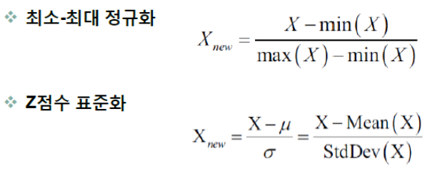

```r
 normalize <-function(x){
        return((x-min(x))/(max(x)-min(x)))
      }
normalize(c(1,2,3,4,5))
```

```
## [1] 0.00 0.25 0.50 0.75 1.00
```

```r
normalize(c(10,20,30,40,50))
```

```
## [1] 0.00 0.25 0.50 0.75 1.00
```

```r
wbcd_train_n<-as.data.frame(lapply(wbcd_train[2:31],normalize))  #lapply(데이터,사용할 함수)
wbcd_test_n<-as.data.frame(lapply(wbcd_test[2:31],normalize))
```

#### 문제254. 훈련데이터를 테스트데이터와 라벨로 나누시오

```r
wbcd_train_label <- wbcd_train[1]
wbcd_test_label <- wbcd_test[1]

wbcd_train_label<- t(wbcd_train_label)
wbcd_test_label<- t(wbcd_test_label)

wbcd_train <- wbcd_train_n
wbcd_test <- wbcd_test_n

# t로 컬럼과 로우데이터를 바꿔주야함
wbcd_train_label<- t(wbcd_train_label)
```

#### knn모델로 훈련시켜서 모델을 만드시오

```r
library(class)
result1 <- knn(train=wbcd_train, test=wbcd_test, cl=wbcd_train_label, k=21)

length(result1)
```

```
## [1] 57
```

> 실습방법 정리  
> 1. 데이터 로드  
> 2. diagnosis를 factor로 변환한다.(for labeling)  
> 3. 데이터 shuffle  
> 4. 필요없는 데이터 정제작업  
> 5. 데이터 정규화  
> 6. train 데이터와 test 데이터로 나눈다.  
> 7. label(정답)과 데이터를 나눈다  
> 8. knn모델 훈련시키기

```r
# 1. 데이터를 로드 한다.

wbcd <-  read.csv("C:/data/wisc_bc_data.csv", header=T,  stringsAsFactors=FALSE)


# 2. diagnosis 를 factor 로 변환한다

wbcd$diagnosis <- factor(wbcd$diagnosis,
                          levels =c("B","M"),
                   labels = c("Benign","Maliganant"))


# 3. 데이터를 shuffle 시킨다.

wbcd_shuffle <- wbcd[sample(nrow(wbcd)), ]


# 4. 데이터에서 id 를 제외 시킨다

 wbcd2 <- wbcd_shuffle[-1]


# 5. 데이터를 정규화 한다.

normalize <- function(x) {
      return ( (x-min(x)) / (max(x) - min(x))  )
                          }

wbcd_n  <- as.data.frame(lapply(wbcd2[2:31],normalize))


# 6. train 데이터와 test 데이터로 9 대 1로 나눈다

train_num<-round(0.9*nrow(wbcd_n),0)
wbcd_train<-wbcd_n[1:train_num,]
wbcd_test<-wbcd_n[(train_num+1):nrow(wbcd_n),]


# 7. train 데이터를 데이터와 라벨로 나누고
#    test  데이터를 데이터와 라벨로 나누시오 ~

wbcd_train_label <- wbcd2[1:train_num,1]
wbcd_test_label <- wbcd2[(train_num+1):nrow(wbcd_n),1]


# 8. knn 모델로 훈련시켜서 모델을 만들고 바로 그 모델에
#   test 데이터를 넣어서 정확도를 확인한다

library(class)
result2 <- knn(train=wbcd_train, test=wbcd_test,                cl=wbcd_train_label, k=17)

# result2


# 9.예측과 실제 데이터를 먼저 확인한다.

library(data.table)
data.table("예측" = result1, "실제" = wbcd_test_label)
```

```
##          예측       실제
##  1: Malignant     Benign
##  2: Malignant     Benign
##  3: Malignant     Benign
##  4: Malignant     Benign
##  5: Malignant     Benign
##  6: Malignant Maliganant
##  7:    Benign     Benign
##  8:    Benign     Benign
##  9:    Benign     Benign
## 10:    Benign Maliganant
## 11: Malignant     Benign
## 12: Malignant Maliganant
## 13: Malignant     Benign
## 14:    Benign     Benign
```

[output cut: 44 more lines]

```r
# 10. 몇개 맞췄고 몇개 못맞췄는지 확인해본다

table(ifelse(wbcd_test_label == result2,"o","x"))
```

```
##
##  o  x
## 55  2
```

```r
# 11. 이 모델의 정확도가 몇 %인지 확인하시오!

prop.table(table(ifelse(wbcd_test_label == result2,"o","x")))
```

```
##
##          o          x
## 0.96491228 0.03508772
```

```r
# 12. 이원 교차표를 그려서 확인하시오

library(gmodels)
CrossTable(x = wbcd_test_label, y = result2, prop.chisq = FALSE)
```

```
##
##
##    Cell Contents
## |-------------------------|
## |                       N |
## |           N / Row Total |
## |           N / Col Total |
## |         N / Table Total |
## |-------------------------|
##
##
## Total Observations in Table:  57
##
##
##                 | result2
## wbcd_test_label |     Benign | Maliganant |  Row Total |
## ----------------|------------|------------|------------|
##          Benign |         40 |          0 |         40 |
##                 |      1.000 |      0.000 |      0.702 |
##                 |      0.952 |      0.000 |            |
##                 |      0.702 |      0.000 |            |
## ----------------|------------|------------|------------|
##      Maliganant |          2 |         15 |         17 |
##                 |      0.118 |      0.882 |      0.298 |
##                 |      0.048 |      1.000 |            |
##                 |      0.035 |      0.263 |            |
## ----------------|------------|------------|------------|
##    Column Total |         42 |         15 |         57 |
##                 |      0.737 |      0.263 |            |
## ----------------|------------|------------|------------|
##
##
```

```r
# 13. 튜닝하자!
```

#### 문제255. FN이 0이 나오도록 튜닝한다.

```r
# 1. 셔플 다시 수행
# 2. k 값 조정

wbcd_shuffle <- wbcd[sample(nrow(wbcd)), ]


wbcd2 <- wbcd_shuffle[-1]


wbcd_n  <- as.data.frame(lapply(wbcd2[2:31],normalize))

train_num<-round(0.9*nrow(wbcd_n),0)
wbcd_train<-wbcd_n[1:train_num,]
wbcd_test<-wbcd_n[(train_num+1):nrow(wbcd_n),]

wbcd_train_label <- wbcd2[1:train_num,1]
wbcd_test_label <- wbcd2[(train_num+1):nrow(wbcd_n),1]

result2 <- knn(train=wbcd_train, test=wbcd_test,                cl=wbcd_train_label, k=17)


data.table("예측" = result1, "실제" = wbcd_test_label)
```

```
##          예측       실제
##  1: Malignant     Benign
##  2: Malignant     Benign
##  3: Malignant     Benign
##  4: Malignant Maliganant
##  5: Malignant     Benign
##  6: Malignant     Benign
##  7:    Benign     Benign
##  8:    Benign     Benign
##  9:    Benign     Benign
## 10:    Benign     Benign
## 11: Malignant Maliganant
## 12: Malignant     Benign
## 13: Malignant     Benign
## 14:    Benign Maliganant
```

[output cut: 44 more lines]

```r
prop.table(table(ifelse(wbcd_test_label == result2,"o","x")))
```

```
##
## o
## 1
```

```r
CrossTable(x = wbcd_test_label, y = result2, prop.chisq = FALSE)
```

```
##
##
##    Cell Contents
## |-------------------------|
## |                       N |
## |           N / Row Total |
## |           N / Col Total |
## |         N / Table Total |
## |-------------------------|
##
##
## Total Observations in Table:  57
##
##
##                 | result2
## wbcd_test_label |     Benign | Maliganant |  Row Total |
## ----------------|------------|------------|------------|
##          Benign |         40 |          0 |         40 |
##                 |      1.000 |      0.000 |      0.702 |
##                 |      1.000 |      0.000 |            |
##                 |      0.702 |      0.000 |            |
## ----------------|------------|------------|------------|
##      Maliganant |          0 |         17 |         17 |
##                 |      0.000 |      1.000 |      0.298 |
##                 |      0.000 |      1.000 |            |
##                 |      0.000 |      0.298 |            |
## ----------------|------------|------------|------------|
##    Column Total |         40 |         17 |         57 |
##                 |      0.702 |      0.298 |            |
## ----------------|------------|------------|------------|
##
##
```

#### 문제256. kbody 데이터를 내려받아 R로 로드하시오

```r
kbody <-  read.csv("C:/data/kbody2.csv", header=F,  stringsAsFactors=FALSE)

kbody$V19 <- factor(kbody$V19,
                          levels =c("표준","복비"),
                   labels = c("표준","복부비만"))

kbody <- na.omit(kbody)

# str(kbody)
# 범주형을 수치형으로 바꾸기
kbody$V1 <- ifelse(kbody$V1 == '남',0,1)

kbody_shuffle <- kbody[sample(nrow(kbody)), ]

# factor로 변환한 부분은 normalize 안됨
# kbody_n  <- as.data.frame(lapply(kbody_shuffle,normalize))

kbody_n  <- as.data.frame(lapply(kbody_shuffle[c(1:18)],normalize))
kbody_n  <- cbind(kbody_n[c(1:18)], kbody[19])
# 노멀라이즈한 부분과 펙터 부분을 합치기 위해 cbind 사용, 수치형데이터만 normalize가 가능
# length(kbody_n)
# nrow(kbody_n)

train_num <- round(nrow(kbody_n) * 0.8, 0)
#
# train_num

kbody_train <- kbody_n[1:train_num,c(1:18)]
kbody_test <- kbody_n[(train_num+1):nrow(kbody_n),c(1:18)]

kbody_train_labels <- kbody_n[1:train_num,19]
kbody_test_labels <- kbody_n[(train_num+1):nrow(kbody_n),19]

# nrow(kbody_train)
# nrow(kbody_test)

library(class)

result1 <- knn(train = kbody_train, test = kbody_test, cl = kbody_train_labels, k=7)

result2 <- knn(train = kbody_train, test = kbody_test, cl = kbody_train_labels, k=15)

result3 <- knn(train = kbody_train, test = kbody_test, cl = kbody_train_labels, k=21)


# check
prop.table(table(ifelse(kbody_test_labels == result1,"o","x")))
```

```
##
##         o         x
## 0.7425783 0.2574217
```

```r
prop.table(table(ifelse(kbody_test_labels == result2,"o","x")))
```

```
##
##         o         x
## 0.7543717 0.2456283
```

```r
prop.table(table(ifelse(kbody_test_labels == result3,"o","x")))
```

```
##
##         o         x
## 0.7547784 0.2452216
```

#### 가장 좋은 k 값을 알아내기 위해 테스트를 수행

```r
# install.packages("caret")
# install.packages("e1071")
# library(caret)
#
# library(e1071)
#
#
# # Setting up train controls
#
# repeats = 3
#
# numbers = 10
#
# tunel = 10
#
# # 랜덤값을 돌리기 위해 사용
# set.seed(1234)
#
# # 최적의 k 값을 알기위해서 test를 어떻게 반복시킬 것인지 반복 방법을 정하는 문법
# # library(caret)에 있는 함수
# x = trainControl(method = "repeatedcv",
#
#                  number = numbers,
#
#                  repeats = repeats,
#
#                  classProbs = TRUE,
#
#                  summaryFunction = twoClassSummary)
#
#
# model1 <- train(diagnosis~. , data = wbcd_train, method = "knn",
#                # 정규화하기
#                preProcess = c("center","scale"),
#                # text 반복 횟수
#                trControl = x,
#                # Repeated O Control
#                metric = "ROC",
#                # tunel = 10
#                tuneLength = tunel)
#
#
# # Summary of model
#
# model1
#
# plot(model1)
```

#### knn 알고리즘

```r
# 0. R 에서 모든 변수 지우기

rm(list=ls())



ls()
```

```
## character(0)
```

```r
# 1. 데이터를 로드 한다.


wbcd <-  read.csv("C:/data/wisc_bc_data.csv", header=T,  stringsAsFactors=FALSE)



# 2. diagnosis 를 factor 로 변환한다



wbcd$diagnosis <- factor(wbcd$diagnosis,

                          levels =c("B","M"),

                   labels = c("Benign","Maliganant"))



# 3. 데이터를 shuffle 시킨다.

set.seed(123)
wbcd_shuffle <- wbcd[sample(nrow(wbcd)), ]





# 4. 데이터에서 id 를 제외 시킨다


wbcd2 <- wbcd_shuffle[-1]



# 5. 데이터를 정규화 한다.



normalize <- function(x) {

      return ( (x-min(x)) / (max(x) - min(x))  )

                          }



wbcd_n  <- as.data.frame(lapply(wbcd2[2:31],normalize))

wbcd_n <- cbind(wbcd2[1], wbcd_n)



# 6. train 데이터와 test 데이터로 9 대 1로 나눈다


train_num<-round(0.9*nrow(wbcd_n),0)

wbcd_train<-wbcd_n[1:train_num,]

wbcd_test<-wbcd_n[(train_num+1):nrow(wbcd_n),]





# 7. train 데이터를 데이터와 라벨로 나누고
#
#    test  데이터를 데이터와 라벨로 나누시오 ~



wbcd_train_label <- wbcd2[1:train_num,1]

wbcd_test_label <- wbcd2[(train_num+1):nrow(wbcd_n),1]



nrow(wbcd_train)
```

```
## [1] 512
```

```r
length(wbcd_train_label)
```

```
## [1] 512
```

```r
nrow(wbcd_test)
```

```
## [1] 57
```

```r
length(wbcd_test_label)
```

```
## [1] 57
```

```r
# 8. (새로운 방법)



library(caret)
library(e1071)





# Setting up train controls

repeats = 3

numbers = 10

tunel = 10

set.seed(123)
x = trainControl(method = "repeatedcv",

                 number = numbers,

                 repeats = repeats,

                 classProbs = TRUE,

                 summaryFunction = twoClassSummary)





model1 <- train(diagnosis~. , data = wbcd_train, method = "knn",

               preProcess = c("center","scale"),

               trControl = x,

               metric = "ROC",

               tuneLength = tunel)



# Summary of model

model1
```

```
## k-Nearest Neighbors
##
## 512 samples
##  30 predictor
##   2 classes: 'Benign', 'Maliganant'
##
## Pre-processing: centered (30), scaled (30)
## Resampling: Cross-Validated (10 fold, repeated 3 times)
## Summary of sample sizes: 461, 461, 461, 461, 461, 461, ...
## Resampling results across tuning parameters:
##
##   k   ROC        Sens       Spec
##    5  0.9841790  0.9865530  0.9070175
##    7  0.9848169  0.9896149  0.9087719
##    9  0.9869609  0.9916982  0.9175439
##   11  0.9877625  0.9916982  0.9105263
##   13  0.9887776  0.9927399  0.9000000
##   15  0.9893607  0.9948232  0.8929825
##   17  0.9891713  0.9968750  0.8859649
##   19  0.9889545  0.9958649  0.8859649
##   21  0.9888756  0.9958333  0.8736842
##   23  0.9884328  0.9968750  0.8719298
##
## ROC was used to select the optimal model using the largest value.
## The final value used for the model was k = 15.
```

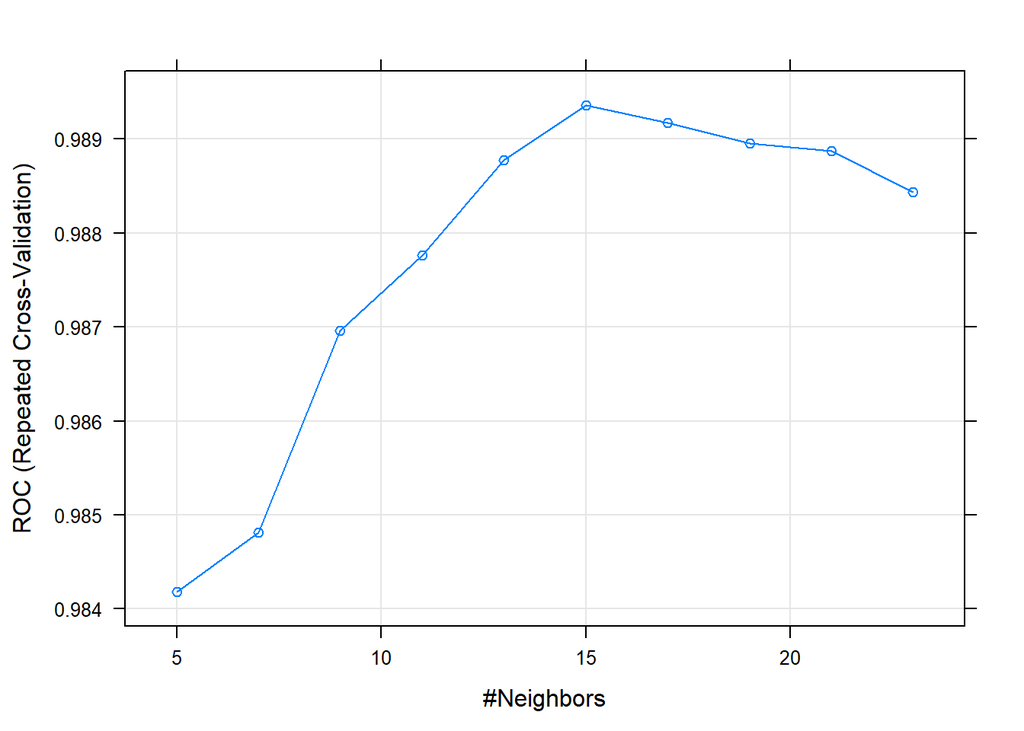

```r
plot(model1)
```

```r
# 8. knn 모델로 훈련시켜서 모델을 만들고 바로 그 모델에
#
#   test 데이터를 넣어서 예측 결과(양성,악성) 를
#
#   추출한다.


library(class)



wbcd_train <- wbcd_train[-1]

wbcd_test <- wbcd_test[-1]



result1 <- knn(train=wbcd_train, test=wbcd_test,

                  cl=wbcd_train_label, k= 15)


#
# result1  <--- 테스트 데이터를 가지고 예측한 결과
#
#                     53명의 환자들의 예측 결과



# 9.  예측과 실제 데이터를 먼저 본다



library(data.table)



# data.table("예측"=result1, "실제"=wbcd_test_label)



# 10. 몇개 맞췄고 몇개 못맞췄는지 확인해본다

#
#
#  table(ifelse(wbcd_test_label==result1,"o","x"))
#

#
#  o  x
#
# 55  2
#


# 11. 이 모델의 정확도가 몇 % 인지 확인하시오 !
#
#
#
# prop.table(table(ifelse(wbcd_test_label==result1,"o","x")) )
#
#          o          x
#
# 0.96491228 0.03508772
#
# >



# 12. 이원 교차표를 그려서 TP,TN,FP,FN 을 확인해보시오



library(gmodels)

CrossTable( x= wbcd_test_label, y= result1,

            prop.chisq=FALSE)
```

```
##
##
##    Cell Contents
## |-------------------------|
## |                       N |
## |           N / Row Total |
## |           N / Col Total |
## |         N / Table Total |
## |-------------------------|
##
##
## Total Observations in Table:  57
##
##
##                 | result1
## wbcd_test_label |     Benign | Maliganant |  Row Total |
## ----------------|------------|------------|------------|
##          Benign |         35 |          0 |         35 |
##                 |      1.000 |      0.000 |      0.614 |
##                 |      1.000 |      0.000 |            |
##                 |      0.614 |      0.000 |            |
## ----------------|------------|------------|------------|
##      Maliganant |          0 |         22 |         22 |
##                 |      0.000 |      1.000 |      0.386 |
##                 |      0.000 |      1.000 |            |
##                 |      0.000 |      0.386 |            |
## ----------------|------------|------------|------------|
##    Column Total |         35 |         22 |         57 |
##                 |      0.614 |      0.386 |            |
## ----------------|------------|------------|------------|
##
##
```

#### set.seed() 난수설정 이해

```r
set.seed(0)

sample(5, replace=TRUE)
```

```
## [1] 5 2 2 3 5
```

```r
sample(10, replace=TRUE)
```

```
##  [1]  3  9 10  7  7  1  3  2  7  4
```

```r
sample(10, replace=TRUE)
```

```
##  [1]  8  5  8 10  4  8 10  3  7  2
```

```r
set.seed(0)

sample(5, replace=TRUE)
```

```
## [1] 5 2 2 3 5
```

```r
sample(10, replace=TRUE)
```

```
##  [1]  3  9 10  7  7  1  3  2  7  4
```

```r
sample(10, replace=TRUE)
```

```
##  [1]  8  5  8 10  4  8 10  3  7  2
```

```r
# 0. R 에서 모든 변수 지우기

rm(list=ls())



ls()
```

```
## character(0)
```

```r
# 1. 데이터를 로드 한다.


wbcd <-  read.csv("C:/data/wisc_bc_data.csv", header=T,  stringsAsFactors=FALSE)



# 2. diagnosis 를 factor 로 변환한다



wbcd$diagnosis <- factor(wbcd$diagnosis,

                          levels =c("B","M"),

                   labels = c("Benign","Maliganant"))



# 3. 데이터를 shuffle 시킨다.

set.seed(18)
wbcd_shuffle <- wbcd[sample(nrow(wbcd)), ]





# 4. 데이터에서 id 를 제외 시킨다


wbcd2 <- wbcd_shuffle[-1]



# 5. 데이터를 정규화 한다.



normalize <- function(x) {

      return ( (x-min(x)) / (max(x) - min(x))  )

                          }



wbcd_n  <- as.data.frame(lapply(wbcd2[2:31],normalize))

wbcd_n <- cbind(wbcd2[1], wbcd_n)



# 6. train 데이터와 test 데이터로 9 대 1로 나눈다


train_num<-round(0.9*nrow(wbcd_n),0)

wbcd_train<-wbcd_n[1:train_num,]

wbcd_test<-wbcd_n[(train_num+1):nrow(wbcd_n),]





# 7. train 데이터를 데이터와 라벨로 나누고
#
#    test  데이터를 데이터와 라벨로 나누시오 ~



wbcd_train_label <- wbcd2[1:train_num,1]

wbcd_test_label <- wbcd2[(train_num+1):nrow(wbcd_n),1]



nrow(wbcd_train)
```

```
## [1] 512
```

```r
length(wbcd_train_label)
```

```
## [1] 512
```

```r
nrow(wbcd_test)
```

```
## [1] 57
```

```r
length(wbcd_test_label)
```

```
## [1] 57
```

```r
# 8. (새로운 방법)



library(caret)

library(e1071)





# Setting up train controls
# reapeats가 높아지면 어떠한 max(k)에 수렴함
repeats = 50

numbers = 10

tunel = 10

# "데이터가 부정확, 불완전 또는 불합리한가 어떤가를 확인하기 위해서 사용되는 처리"
set.seed(1234)
x = trainControl(method = "repeatedcv",
                 # numbers만큼 쪼개겠다. 1개를 validation, 나머지 train 반복
                 number = numbers,
                 # number 한바퀴가 repeat = 1
                 repeats = repeats,

                 classProbs = TRUE,

                 summaryFunction = twoClassSummary)


model1 <- train(diagnosis~. , data = wbcd_train, method = "knn",

               preProcess = c("center","scale"),

               trControl = x,

               metric = "ROC",

               tuneLength = tunel)



# Summary of model

model1
```

```
## k-Nearest Neighbors
##
## 512 samples
##  30 predictor
##   2 classes: 'Benign', 'Maliganant'
##
## Pre-processing: centered (30), scaled (30)
## Resampling: Cross-Validated (10 fold, repeated 50 times)
## Summary of sample sizes: 461, 461, 461, 460, 461, 460, ...
## Resampling results across tuning parameters:
##
##   k   ROC        Sens       Spec
##    5  0.9914003  0.9889867  0.9340175
##    7  0.9934833  0.9900379  0.9312339
##    9  0.9952622  0.9911439  0.9355731
##   11  0.9956729  0.9925701  0.9324094
##   13  0.9962711  0.9923902  0.9170936
##   15  0.9966022  0.9950530  0.9058830
##   17  0.9965561  0.9940587  0.9001871
##   19  0.9964256  0.9950530  0.8974444
##   21  0.9964408  0.9963598  0.8932982
##   23  0.9963573  0.9957992  0.8907427
##
## ROC was used to select the optimal model using the largest value.
## The final value used for the model was k = 15.
```

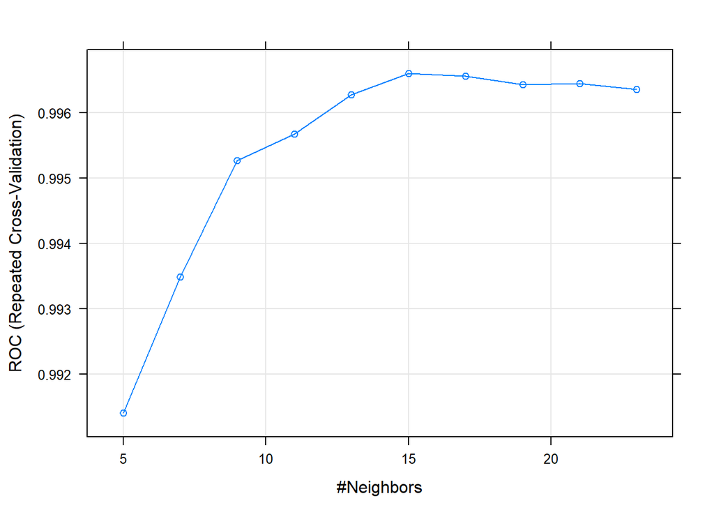

```r
plot(model1)
```

```r
# 8. knn 모델로 훈련시켜서 모델을 만들고 바로 그 모델에
#
#   test 데이터를 넣어서 예측 결과(양성,악성) 를
#
#   추출한다.


library(class)



wbcd_train <- wbcd_train[-1]

wbcd_test <- wbcd_test[-1]



result1 <- knn(train=wbcd_train, test=wbcd_test,

                  cl=wbcd_train_label, k= max(model1$bestTune))


# 9.  예측과 실제 데이터를 먼저 본다



library(data.table)



# data.table("예측"=result1, "실제"=wbcd_test_label)



# 10. 몇개 맞췄고 몇개 못맞췄는지 확인해본다

#
#  table(ifelse(wbcd_test_label==result1,"o","x"))


# 11. 이 모델의 정확도가 몇 % 인지 확인하시오 !
#
prop.table(table(ifelse(wbcd_test_label==result1,"o","x")) )
```

```
##
##          o          x
## 0.94736842 0.05263158
```

```r
# 12. 이원 교차표를 그려서 TP,TN,FP,FN 을 확인해보시오


library(gmodels)

CrossTable( x= wbcd_test_label, y= result1,

            prop.chisq=FALSE)
```

```
##
##
##    Cell Contents
## |-------------------------|
## |                       N |
## |           N / Row Total |
## |           N / Col Total |
## |         N / Table Total |
## |-------------------------|
##
##
## Total Observations in Table:  57
##
##
##                 | result1
## wbcd_test_label |     Benign | Maliganant |  Row Total |
## ----------------|------------|------------|------------|
##          Benign |         34 |          0 |         34 |
##                 |      1.000 |      0.000 |      0.596 |
##                 |      0.919 |      0.000 |            |
##                 |      0.596 |      0.000 |            |
## ----------------|------------|------------|------------|
##      Maliganant |          3 |         20 |         23 |
##                 |      0.130 |      0.870 |      0.404 |
##                 |      0.081 |      1.000 |            |
##                 |      0.053 |      0.351 |            |
## ----------------|------------|------------|------------|
##    Column Total |         37 |         20 |         57 |
##                 |      0.649 |      0.351 |            |
## ----------------|------------|------------|------------|
##
##
```

#### 문제258. 위의 스크립트를 묶어서 함수로 만드는데 데이터를 물어보게하고 label을 물어보게 해서 이 데이터에 맞는 가장 적당한 k가 무엇인지 출력되는 함수를 생성하기 위해서 지금 스크립트에서 우리가 그래프만 보고 최대 k가 무엇인지 알았는데 명령어로 R명령어로 가장 좋은 k가 뭔지 출력되게 하시오

```r
rm(list=ls())



ls()
```

```
## character(0)
```

```r
# 1. 데이터를 로드 한다.


wbcd <-  read.csv("C:/data/wisc_bc_data.csv", header=T,  stringsAsFactors=FALSE)



# 2. diagnosis 를 factor 로 변환한다



wbcd$diagnosis <- factor(wbcd$diagnosis,

                          levels =c("B","M"),

                   labels = c("Benign","Maliganant"))



# 3. 데이터를 shuffle 시킨다.

set.seed(18)
wbcd_shuffle <- wbcd[sample(nrow(wbcd)), ]





# 4. 데이터에서 id 를 제외 시킨다


wbcd2 <- wbcd_shuffle[-1]



# 5. 데이터를 정규화 한다.



normalize <- function(x) {

      return ( (x-min(x)) / (max(x) - min(x))  )

                          }



wbcd_n  <- as.data.frame(lapply(wbcd2[2:31],normalize))

wbcd_n <- cbind(wbcd2[1], wbcd_n)



# 6. train 데이터와 test 데이터로 9 대 1로 나눈다


train_num<-round(0.9*nrow(wbcd_n),0)

wbcd_train<-wbcd_n[1:train_num,]

wbcd_test<-wbcd_n[(train_num+1):nrow(wbcd_n),]





# 7. train 데이터를 데이터와 라벨로 나누고
#
#    test  데이터를 데이터와 라벨로 나누시오 ~



wbcd_train_label <- wbcd2[1:train_num,1]

wbcd_test_label <- wbcd2[(train_num+1):nrow(wbcd_n),1]



nrow(wbcd_train)
```

```
## [1] 512
```

```r
length(wbcd_train_label)
```

```
## [1] 512
```

```r
nrow(wbcd_test)
```

```
## [1] 57
```

```r
length(wbcd_test_label)
```

```
## [1] 57
```

```r
# 8. (새로운 방법)



library(caret)

library(e1071)





# Setting up train controls
# reapeats가 높아지면 어떠한 max(k)에 수렴함
repeats = 50

numbers = 10

tunel = 10

# "데이터가 부정확, 불완전 또는 불합리한가 어떤가를 확인하기 위해서 사용되는 처리"
set.seed(1234)
x = trainControl(method = "repeatedcv",
                 # numbers만큼 쪼개겠다. 1개를 validation, 나머지 train 반복
                 number = numbers,
                 # number 한바퀴가 repeat = 1
                 repeats = repeats,

                 classProbs = TRUE,

                 summaryFunction = twoClassSummary)


model1 <- train(diagnosis~. , data = wbcd_train, method = "knn",

               preProcess = c("center","scale"),

               trControl = x,

               metric = "ROC",

               tuneLength = tunel)



# Summary of model

model1
```

```
## k-Nearest Neighbors
##
## 512 samples
##  30 predictor
##   2 classes: 'Benign', 'Maliganant'
##
## Pre-processing: centered (30), scaled (30)
## Resampling: Cross-Validated (10 fold, repeated 50 times)
## Summary of sample sizes: 461, 461, 461, 460, 461, 460, ...
## Resampling results across tuning parameters:
##
##   k   ROC        Sens       Spec
##    5  0.9914003  0.9889867  0.9340175
##    7  0.9934833  0.9900379  0.9312339
##    9  0.9952622  0.9911439  0.9355731
##   11  0.9956729  0.9925701  0.9324094
##   13  0.9962711  0.9923902  0.9170936
##   15  0.9966022  0.9950530  0.9058830
##   17  0.9965561  0.9940587  0.9001871
##   19  0.9964256  0.9950530  0.8974444
##   21  0.9964408  0.9963598  0.8932982
##   23  0.9963573  0.9957992  0.8907427
##
## ROC was used to select the optimal model using the largest value.
## The final value used for the model was k = 15.
```

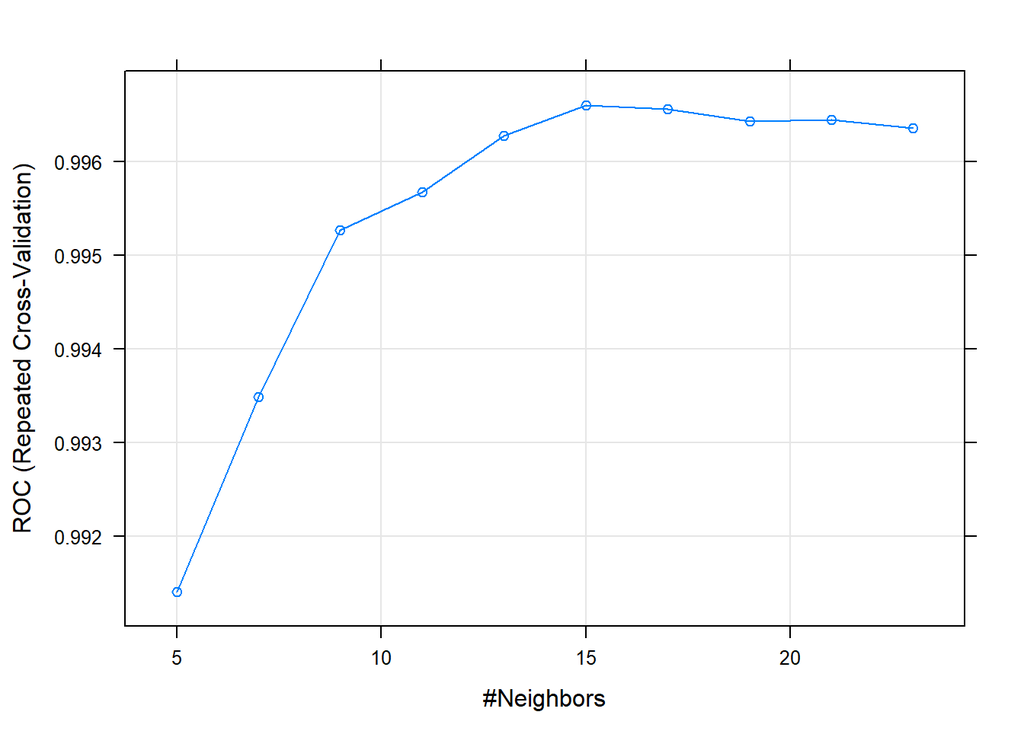

```r
plot(model1)
```

```r
max(model1$bestTune)
```

```
## [1] 15
```

#### 문제259-263. knn 머신러닝 알고리즘을 사용하는 코드를 함수로 생성하시오

```r
knn_function <- function(){

  setwd("C:/data")
  #
  # data <- readline("분석할 csv파일명을 입력하세요 ")
  #

  data<-file.choose()
  table1 <- na.omit(read.csv(data, stringsAsFactors = FALSE))

  col1 <- menu(colnames(table1), title = "라벨이 될 컬럼 이름을 입력하세요 ")

  col_n <- menu(colnames(table1), title = "제거할 컬럼 이름을 입력하세요 ")

  # colname으로 받아야함
  col1 <- colnames(table1)[col1]

  normalize <- function(x) {
    return( (x-min(x))/ ( max(x)-min(x)))
  }

  # 불필요한 컬럼 삭제하기
  table1 <- table1[-col_n]

  # which : column이 위치한 숫자가 출력
  ncol <- which(colnames(table1) == col1)

  # 정규화
  table_n <- as.data.frame(lapply(table1[, -ncol],normalize))

  # training data 와 test data 바꾸기
  mm<-round(nrow(table_n) * 9/10)

  table_train <- table_n[1:mm, ]
  table_test  <- table_n[(mm+1):nrow(table_n), ]

  table_train_label <- table1[1:mm, col1]
  table_test_label  <- table1[(mm+1):nrow(table_n), col1]


  # k 값 자동 생성

  library(caret)

  library(e1071)

  repeats = 20

  numbers = 10

  tunel = 10

  # "데이터가 부정확, 불완전 또는 불합리한가 어떤가를 확인하기 위해서 사용되는 처리"
  set.seed(1234)
  x = trainControl(method = "repeatedcv",

                   number = numbers,

                   repeats = repeats,

                   classProbs = TRUE,

                   summaryFunction = twoClassSummary)


  # normalize에서 label이 사라짐 -> cbind로 묶음

  model1 <- train(label~. , data = cbind(label = table_train_label, table_train), method = "knn",

                 preProcess = c("center","scale"),

                 trControl = x,

                 metric = "ROC",

                 tuneLength = tunel)



  # Summary of model
  k_n <- max(model1$bestTune)


  # knn 알고리즘
  library(class)

  result1 <- knn(train=table_train, test=table_test, cl= table_train_label, k = k_n )

  prop.table( table(ifelse(table1[(mm+1):nrow(table_n), col1]==result1,"o","x" )))

  # 이원교차표
  library(gmodels)

  CrossTable( x= table_test_label, y= result1, prop.chisq=FALSE)

}

 # knn_function()
```

#### 문제264. 환자(patient15)가 유방암이 악성인지 양성인지를 예측하는 자동화 knn 모델을 완성시키시오.

```r
knn_function <- function(){

  rm()
  setwd("C:/data")
  #
  # data <- readline("분석할 csv파일명을 입력하세요 ")
  #

  data<-file.choose("분석할 csv파일명을 입력하세요")

  table1 <- na.omit(read.csv(data, stringsAsFactors = FALSE))

  col <- menu(colnames(table1), title = "라벨이 될 컬럼 이름을 입력하세요 ")

  col_n <- menu(colnames(table1), title = "제거할 컬럼 이름을 입력하세요 ")

  # colname으로 받아야함
  col1 <- colnames(table1)[col]

  normalize <- function(x) {
    return( (x-min(x))/ ( max(x)-min(x)))
  }

  # 불필요한 컬럼 삭제하기
  table1 <- table1[-col_n]

  # which : column이 위치한 숫자가 출력
  ncol <- which(colnames(table1) == col1)

  # 정규화
  table_n <- as.data.frame(lapply(table1[, -ncol],normalize))

  # training data 와 test data 바꾸기
  mm<-round(nrow(table_n) * 9/10)

  table_train <- table_n[1:mm, ]
  table_test  <- table_n[(mm+1):nrow(table_n), ]

  table_train_label <- table1[1:mm, col1]
  table_test_label  <- table1[(mm+1):nrow(table_n), col1]


  # k 값 자동 생성

  library(caret)

  library(e1071)

  repeats = 20

  numbers = 10

  tunel = 10

  # "데이터가 부정확, 불완전 또는 불합리한가 어떤가를 확인하기 위해서 사용되는 처리"
  set.seed(1234)
  x = trainControl(method = "repeatedcv",

                   number = numbers,

                   repeats = repeats,

                   classProbs = TRUE,

                   summaryFunction = twoClassSummary)


  # normalize에서 label이 사라짐 -> cbind로 묶음

  model1 <- train(label~. , data = cbind(label = table_train_label, table_train), method = "knn",

                 preProcess = c("center","scale"),

                 trControl = x,

                 metric = "ROC",

                 tuneLength = tunel)



  # Summary of model
  k_n <- max(model1$bestTune)


  # knn 알고리즘
  library(class)

  result1 <- knn(train=table_train, test=table_test, cl= table_train_label, k = k_n )

  # 확률구하기
  prop.table( table(ifelse(table1[(mm+1):nrow(table_n), col1]==result1,"o","x" )))

  # 이원교차표
  library(gmodels)

  CrossTable( x= table_test_label, y= result1, prop.chisq=FALSE)



  # 예측할 환자정보

  patient <- file.choose()
  table2 <- na.omit(read.csv(patient))
  # print(table2)

  # table3 <- rbind(table1, table2[-col_n])
  #
  # ncol <- which(colnames(table3) == col1)
  #
  # # 정규화
  # table_n2 <- as.data.frame(lapply(table3[, -ncol], normalize))
  #
  # nrow <- nrow(table_n2)
  # table_train2 <- table_n2[1:(nrow-1), ]
  # table_test2  <- table_n2[nrow, ]

  # table_train_label2 <- table3[1:(nrow-1), col1]

  # rbind 해서 normalize하면 안됨. 트레이닝은 전체 테이터로만 해야 함.
  col2 <- colnames(table2)[col]

  table2 <- table2[-col_n]

  # print(table2)
  ncol <- which(colnames(table2) == col2)
  table_test2 <- table2[,-ncol]
  table_test2 <- normalize(table_test2)

  # print(table_test2)

  result2 <- knn(train=table_train, test = table_test2, cl= table_train_label, k = k_n )

  return(paste(result2,"(으)로 예측됩니다"))
}

 # knn_function()
```